# Risk Factor Analysis

## Outcome Variable

**Outcome Variable:** ever_stunted

## Predictor Variables

**Intervention Variable:** hhwealth_quart

**Adjustment Set:**

unadjusted

## Stratifying Variables

The analysis was stratified on these variable(s):

- agecat
- studyid
- country

## Data Summary

| agecat | studyid | country | hhwealth_quart | ever_stunted | n_cell | n |
| --- | --- | --- | --- | --- | --- | --- |
| 0-24 months | COHORTS | GUATEMALA | Wealth Q4 | 0 | 130 | 1278 |
| 0-24 months | COHORTS | GUATEMALA | Wealth Q4 | 1 | 355 | 1278 |
| 0-24 months | COHORTS | GUATEMALA | Wealth Q1 | 0 | 47 | 1278 |
| 0-24 months | COHORTS | GUATEMALA | Wealth Q1 | 1 | 198 | 1278 |
| 0-24 months | COHORTS | GUATEMALA | Wealth Q2 | 0 | 45 | 1278 |
| 0-24 months | COHORTS | GUATEMALA | Wealth Q2 | 1 | 215 | 1278 |
| 0-24 months | COHORTS | GUATEMALA | Wealth Q3 | 0 | 70 | 1278 |
| 0-24 months | COHORTS | GUATEMALA | Wealth Q3 | 1 | 218 | 1278 |
| 0-24 months | COHORTS | PHILIPPINES | Wealth Q4 | 0 | 370 | 3057 |
| 0-24 months | COHORTS | PHILIPPINES | Wealth Q4 | 1 | 473 | 3057 |
| 0-24 months | COHORTS | PHILIPPINES | Wealth Q1 | 0 | 195 | 3057 |
| 0-24 months | COHORTS | PHILIPPINES | Wealth Q1 | 1 | 492 | 3057 |
| 0-24 months | COHORTS | PHILIPPINES | Wealth Q2 | 0 | 157 | 3057 |
| 0-24 months | COHORTS | PHILIPPINES | Wealth Q2 | 1 | 385 | 3057 |
| 0-24 months | COHORTS | PHILIPPINES | Wealth Q3 | 0 | 236 | 3057 |
| 0-24 months | COHORTS | PHILIPPINES | Wealth Q3 | 1 | 749 | 3057 |
| 0-6 months | COHORTS | GUATEMALA | Wealth Q4 | 0 | 277 | 1037 |
| 0-6 months | COHORTS | GUATEMALA | Wealth Q4 | 1 | 105 | 1037 |
| 0-6 months | COHORTS | GUATEMALA | Wealth Q1 | 0 | 127 | 1037 |
| 0-6 months | COHORTS | GUATEMALA | Wealth Q1 | 1 | 70 | 1037 |
| 0-6 months | COHORTS | GUATEMALA | Wealth Q2 | 0 | 132 | 1037 |
| 0-6 months | COHORTS | GUATEMALA | Wealth Q2 | 1 | 73 | 1037 |
| 0-6 months | COHORTS | GUATEMALA | Wealth Q3 | 0 | 165 | 1037 |
| 0-6 months | COHORTS | GUATEMALA | Wealth Q3 | 1 | 88 | 1037 |
| 0-6 months | COHORTS | PHILIPPINES | Wealth Q4 | 0 | 689 | 3057 |
| 0-6 months | COHORTS | PHILIPPINES | Wealth Q4 | 1 | 154 | 3057 |
| 0-6 months | COHORTS | PHILIPPINES | Wealth Q1 | 0 | 506 | 3057 |
| 0-6 months | COHORTS | PHILIPPINES | Wealth Q1 | 1 | 181 | 3057 |
| 0-6 months | COHORTS | PHILIPPINES | Wealth Q2 | 0 | 398 | 3057 |
| 0-6 months | COHORTS | PHILIPPINES | Wealth Q2 | 1 | 144 | 3057 |
| 0-6 months | COHORTS | PHILIPPINES | Wealth Q3 | 0 | 733 | 3057 |
| 0-6 months | COHORTS | PHILIPPINES | Wealth Q3 | 1 | 252 | 3057 |
| 6-24 months | COHORTS | GUATEMALA | Wealth Q4 | 0 | 90 | 848 |
| 6-24 months | COHORTS | GUATEMALA | Wealth Q4 | 1 | 250 | 848 |
| 6-24 months | COHORTS | GUATEMALA | Wealth Q1 | 0 | 32 | 848 |
| 6-24 months | COHORTS | GUATEMALA | Wealth Q1 | 1 | 128 | 848 |
| 6-24 months | COHORTS | GUATEMALA | Wealth Q2 | 0 | 30 | 848 |
| 6-24 months | COHORTS | GUATEMALA | Wealth Q2 | 1 | 142 | 848 |
| 6-24 months | COHORTS | GUATEMALA | Wealth Q3 | 0 | 46 | 848 |
| 6-24 months | COHORTS | GUATEMALA | Wealth Q3 | 1 | 130 | 848 |
| 6-24 months | COHORTS | PHILIPPINES | Wealth Q4 | 0 | 309 | 2121 |
| 6-24 months | COHORTS | PHILIPPINES | Wealth Q4 | 1 | 319 | 2121 |
| 6-24 months | COHORTS | PHILIPPINES | Wealth Q1 | 0 | 125 | 2121 |
| 6-24 months | COHORTS | PHILIPPINES | Wealth Q1 | 1 | 311 | 2121 |
| 6-24 months | COHORTS | PHILIPPINES | Wealth Q2 | 0 | 129 | 2121 |
| 6-24 months | COHORTS | PHILIPPINES | Wealth Q2 | 1 | 241 | 2121 |
| 6-24 months | COHORTS | PHILIPPINES | Wealth Q3 | 0 | 190 | 2121 |
| 6-24 months | COHORTS | PHILIPPINES | Wealth Q3 | 1 | 497 | 2121 |

The following strata were considered:

- agecat: 0-24 months, studyid: COHORTS, country: GUATEMALA
- agecat: 0-24 months, studyid: COHORTS, country: PHILIPPINES
- agecat: 0-6 months, studyid: COHORTS, country: GUATEMALA
- agecat: 0-6 months, studyid: COHORTS, country: PHILIPPINES
- agecat: 6-24 months, studyid: COHORTS, country: GUATEMALA
- agecat: 6-24 months, studyid: COHORTS, country: PHILIPPINES

## Methods Detail

We’re interested in the causal parameters $E[Y_a]$ for all values of $a \in \mathcal{A}$. These parameters represent the mean outcome if, possibly contrary to fact, we intervened to set all units to have $A=a$. Under the randomization and positivity assumptions, these are identified by the statistical parameters $\psi_a=E_W[E_{Y|A,W}(Y|A=a,W)]$. In addition, we’re interested in the mean of $Y$, $E[Y]$ under no intervention (the observed mean). We will estimate these parameters by using SuperLearner to fit the relevant likelihood factors – $E_{Y|A,W}(Y|A=a,W)$ and $p(A=a|W)$, and then updating our likelihood fit using a joint TMLE.

For unadjusted analyses ($W=\{\}$), initial likelihoods were estimated using Lrnr_glm to estimate the simple $E(Y|A)$ and Lrnr_mean to estimate $p(A)$. For adjusted analyses, a small library containing Lrnr_glmnet, Lrnr_xgboost, and Lrnr_mean was used.

Having estimated these parameters, we will then use the delta method to estimate relative risks and attributable risks relative to a prespecified baseline level of $A$.

# Results Detail

## Results Plots

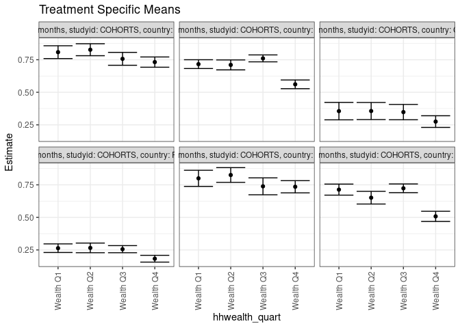

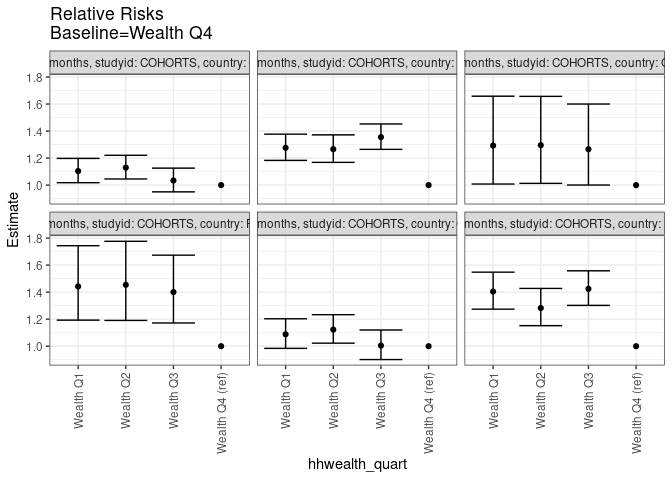

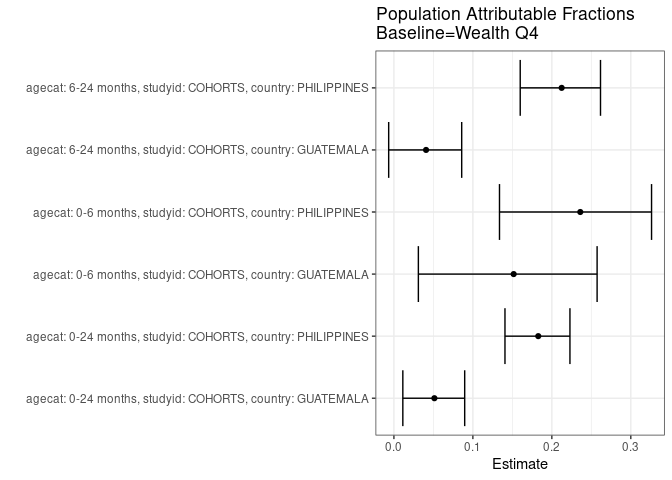

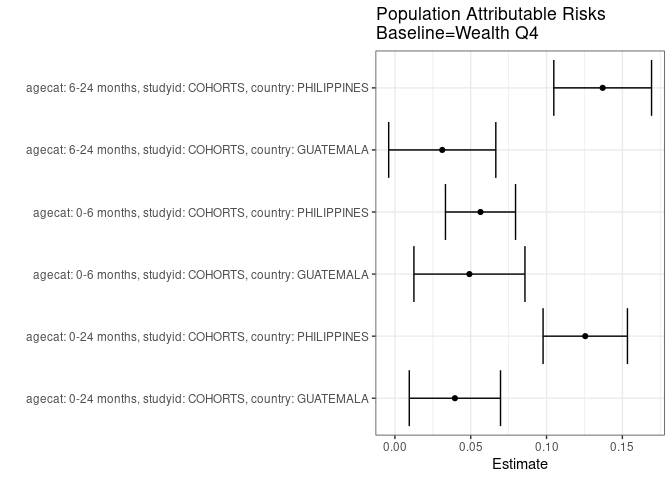

## Results Table

### Parameter: TSM

| agecat | studyid | country | intervention_level | baseline_level | estimate | ci_lower | ci_upper |
| --- | --- | --- | --- | --- | --- | --- | --- |
| 0-24 months | COHORTS | GUATEMALA | Wealth Q4 | NA | 0.7319588 | 0.6925229 | 0.7713946 |
| 0-24 months | COHORTS | GUATEMALA | Wealth Q1 | NA | 0.8081633 | 0.7588402 | 0.8574864 |
| 0-24 months | COHORTS | GUATEMALA | Wealth Q2 | NA | 0.8269231 | 0.7809204 | 0.8729258 |
| 0-24 months | COHORTS | GUATEMALA | Wealth Q3 | NA | 0.7569444 | 0.7073873 | 0.8065016 |
| 0-24 months | COHORTS | PHILIPPINES | Wealth Q4 | NA | 0.5610913 | 0.5275864 | 0.5945963 |
| 0-24 months | COHORTS | PHILIPPINES | Wealth Q1 | NA | 0.7161572 | 0.6824375 | 0.7498769 |
| 0-24 months | COHORTS | PHILIPPINES | Wealth Q2 | NA | 0.7103321 | 0.6721376 | 0.7485266 |
| 0-24 months | COHORTS | PHILIPPINES | Wealth Q3 | NA | 0.7604061 | 0.7337460 | 0.7870662 |
| 0-6 months | COHORTS | GUATEMALA | Wealth Q4 | NA | 0.2748691 | 0.2300775 | 0.3196608 |
| 0-6 months | COHORTS | GUATEMALA | Wealth Q1 | NA | 0.3553299 | 0.2884634 | 0.4221965 |
| 0-6 months | COHORTS | GUATEMALA | Wealth Q2 | NA | 0.3560976 | 0.2905170 | 0.4216781 |
| 0-6 months | COHORTS | GUATEMALA | Wealth Q3 | NA | 0.3478261 | 0.2891096 | 0.4065426 |
| 0-6 months | COHORTS | PHILIPPINES | Wealth Q4 | NA | 0.1826809 | 0.1565925 | 0.2087693 |
| 0-6 months | COHORTS | PHILIPPINES | Wealth Q1 | NA | 0.2634643 | 0.2305187 | 0.2964100 |
| 0-6 months | COHORTS | PHILIPPINES | Wealth Q2 | NA | 0.2656827 | 0.2284912 | 0.3028741 |
| 0-6 months | COHORTS | PHILIPPINES | Wealth Q3 | NA | 0.2558376 | 0.2285844 | 0.2830907 |
| 6-24 months | COHORTS | GUATEMALA | Wealth Q4 | NA | 0.7352941 | 0.6883720 | 0.7822162 |
| 6-24 months | COHORTS | GUATEMALA | Wealth Q1 | NA | 0.8000000 | 0.7379839 | 0.8620161 |
| 6-24 months | COHORTS | GUATEMALA | Wealth Q2 | NA | 0.8255814 | 0.7688379 | 0.8823249 |
| 6-24 months | COHORTS | GUATEMALA | Wealth Q3 | NA | 0.7386364 | 0.6736854 | 0.8035874 |
| 6-24 months | COHORTS | PHILIPPINES | Wealth Q4 | NA | 0.5079618 | 0.4688520 | 0.5470716 |
| 6-24 months | COHORTS | PHILIPPINES | Wealth Q1 | NA | 0.7133028 | 0.6708451 | 0.7557604 |
| 6-24 months | COHORTS | PHILIPPINES | Wealth Q2 | NA | 0.6513514 | 0.6027832 | 0.6999195 |
| 6-24 months | COHORTS | PHILIPPINES | Wealth Q3 | NA | 0.7234352 | 0.6899795 | 0.7568909 |

### Parameter: E(Y)

| agecat | studyid | country | intervention_level | baseline_level | estimate | ci_lower | ci_upper |
| --- | --- | --- | --- | --- | --- | --- | --- |
| 0-24 months | COHORTS | GUATEMALA | NA | NA | 0.7715180 | 0.7484902 | 0.7945458 |
| 0-24 months | COHORTS | PHILIPPINES | NA | NA | 0.6866209 | 0.6701747 | 0.7030670 |
| 0-6 months | COHORTS | GUATEMALA | NA | NA | 0.3240116 | 0.2955133 | 0.3525098 |
| 0-6 months | COHORTS | PHILIPPINES | NA | NA | 0.2391233 | 0.2240003 | 0.2542464 |
| 6-24 months | COHORTS | GUATEMALA | NA | NA | 0.7665094 | 0.7380190 | 0.7949999 |
| 6-24 months | COHORTS | PHILIPPINES | NA | NA | 0.6449788 | 0.6246093 | 0.6653483 |

### Parameter: RR

| agecat | studyid | country | intervention_level | baseline_level | estimate | ci_lower | ci_upper |
| --- | --- | --- | --- | --- | --- | --- | --- |
| 0-24 months | COHORTS | GUATEMALA | Wealth Q4 | Wealth Q4 | 1.000000 | 1.0000000 | 1.000000 |
| 0-24 months | COHORTS | GUATEMALA | Wealth Q1 | Wealth Q4 | 1.104110 | 1.0177865 | 1.197756 |
| 0-24 months | COHORTS | GUATEMALA | Wealth Q2 | Wealth Q4 | 1.129740 | 1.0455504 | 1.220709 |
| 0-24 months | COHORTS | GUATEMALA | Wealth Q3 | Wealth Q4 | 1.034135 | 0.9500670 | 1.125643 |
| 0-24 months | COHORTS | PHILIPPINES | Wealth Q4 | Wealth Q4 | 1.000000 | 1.0000000 | 1.000000 |
| 0-24 months | COHORTS | PHILIPPINES | Wealth Q1 | Wealth Q4 | 1.276365 | 1.1829036 | 1.377210 |
| 0-24 months | COHORTS | PHILIPPINES | Wealth Q2 | Wealth Q4 | 1.265983 | 1.1682346 | 1.371910 |
| 0-24 months | COHORTS | PHILIPPINES | Wealth Q3 | Wealth Q4 | 1.355227 | 1.2645586 | 1.452396 |
| 0-6 months | COHORTS | GUATEMALA | Wealth Q4 | Wealth Q4 | 1.000000 | 1.0000000 | 1.000000 |
| 0-6 months | COHORTS | GUATEMALA | Wealth Q1 | Wealth Q4 | 1.292724 | 1.0078505 | 1.658119 |
| 0-6 months | COHORTS | GUATEMALA | Wealth Q2 | Wealth Q4 | 1.295517 | 1.0130853 | 1.656686 |
| 0-6 months | COHORTS | GUATEMALA | Wealth Q3 | Wealth Q4 | 1.265424 | 1.0007772 | 1.600055 |
| 0-6 months | COHORTS | PHILIPPINES | Wealth Q4 | Wealth Q4 | 1.000000 | 1.0000000 | 1.000000 |
| 0-6 months | COHORTS | PHILIPPINES | Wealth Q1 | Wealth Q4 | 1.442211 | 1.1928649 | 1.743677 |
| 0-6 months | COHORTS | PHILIPPINES | Wealth Q2 | Wealth Q4 | 1.454354 | 1.1907540 | 1.776307 |
| 0-6 months | COHORTS | PHILIPPINES | Wealth Q3 | Wealth Q4 | 1.400462 | 1.1719149 | 1.673579 |
| 6-24 months | COHORTS | GUATEMALA | Wealth Q4 | Wealth Q4 | 1.000000 | 1.0000000 | 1.000000 |
| 6-24 months | COHORTS | GUATEMALA | Wealth Q1 | Wealth Q4 | 1.088000 | 0.9840624 | 1.202916 |
| 6-24 months | COHORTS | GUATEMALA | Wealth Q2 | Wealth Q4 | 1.122791 | 1.0222733 | 1.233192 |
| 6-24 months | COHORTS | GUATEMALA | Wealth Q3 | Wealth Q4 | 1.004546 | 0.9011229 | 1.119838 |
| 6-24 months | COHORTS | PHILIPPINES | Wealth Q4 | Wealth Q4 | 1.000000 | 1.0000000 | 1.000000 |
| 6-24 months | COHORTS | PHILIPPINES | Wealth Q1 | Wealth Q4 | 1.404245 | 1.2740246 | 1.547775 |
| 6-24 months | COHORTS | PHILIPPINES | Wealth Q2 | Wealth Q4 | 1.282284 | 1.1519556 | 1.427358 |
| 6-24 months | COHORTS | PHILIPPINES | Wealth Q3 | Wealth Q4 | 1.424192 | 1.3018550 | 1.558026 |

### Parameter: PAR

| agecat | studyid | country | intervention_level | baseline_level | estimate | ci_lower | ci_upper |
| --- | --- | --- | --- | --- | --- | --- | --- |
| 0-24 months | COHORTS | GUATEMALA | Wealth Q4 | NA | 0.0395592 | 0.0094747 | 0.0696438 |
| 0-24 months | COHORTS | PHILIPPINES | Wealth Q4 | NA | 0.1255295 | 0.0977099 | 0.1533492 |
| 0-6 months | COHORTS | GUATEMALA | Wealth Q4 | NA | 0.0491425 | 0.0125320 | 0.0857529 |
| 0-6 months | COHORTS | PHILIPPINES | Wealth Q4 | NA | 0.0564424 | 0.0333352 | 0.0795497 |
| 6-24 months | COHORTS | GUATEMALA | Wealth Q4 | NA | 0.0312153 | -0.0041102 | 0.0665408 |
| 6-24 months | COHORTS | PHILIPPINES | Wealth Q4 | NA | 0.1370170 | 0.1047879 | 0.1692461 |

### Parameter: PAF

| agecat | studyid | country | intervention_level | baseline_level | estimate | ci_lower | ci_upper |
| --- | --- | --- | --- | --- | --- | --- | --- |
| 0-24 months | COHORTS | GUATEMALA | Wealth Q4 | NA | 0.0512745 | 0.0112993 | 0.0896335 |
| 0-24 months | COHORTS | PHILIPPINES | Wealth Q4 | NA | 0.1828222 | 0.1406470 | 0.2229275 |
| 0-6 months | COHORTS | GUATEMALA | Wealth Q4 | NA | 0.1516688 | 0.0309755 | 0.2573297 |
| 0-6 months | COHORTS | PHILIPPINES | Wealth Q4 | NA | 0.2360390 | 0.1337103 | 0.3262803 |
| 6-24 months | COHORTS | GUATEMALA | Wealth Q4 | NA | 0.0407240 | -0.0066252 | 0.0858460 |
| 6-24 months | COHORTS | PHILIPPINES | Wealth Q4 | NA | 0.2124364 | 0.1599614 | 0.2616335 |